# Sesion2_Actividad

2024-02-05

## Chunk de carga de paquetes, definición de variables, etc.

Este chunk debería marcarse con echo=FALSE y message=FALSE. ¿Tal vez los demás también? Esto ya dependerá de las preferencias personales de cada quien y el cómo quiere presentar sus resultados.

```r
library(coronavirus)
library(tidyverse)
casos <- coronavirus::coronavirus
```

## Antecedentes

Se empieza definiendo un poco de contexto en 3 párrafos:

- ¿Qué es el COVID19? Es un virus, se transmite por vía aerea, causa diversos síntomas, etc…
- ¿Cuál fue la situación en México entre 2020 y 2022? ¿Cuándo se tuvieron los primeros contagios? ¿Qué medidas se tomaron? ¿Cómo se establecieron los programas de prevención y vacunación? Estas fueron algunas de las cuestiones más relevantes.
- ¿Cuál es el contexto de los datos que estamos usando? Se recomienda revisar el github del autor del paquete [https://github.com/RamiKrispin/coronavirus] para acceder a los detalles de los datos. También se puede probar con ??coronavirus en RStudio.

## Materiales y métodos

- Se recomienda revisar el github del autor del paquete [https://github.com/RamiKrispin/coronavirus] para acceder a los detalles de los datos. También se puede probar con ??coronavirus en RStudio.

Escribir un párrafo para definir las ecuaciones usadas para medir el impacto de una enfermedad:

- $TasaDeIncidencia = NuevosCasos / Población \times 100,000$
- $TasaDeMortalidad = Defunciones / Población \times 100,000$

## Resultados

- Nuevos casos confirmados en el tiempo (línea de tiempo sobre casos a nivel mundial).

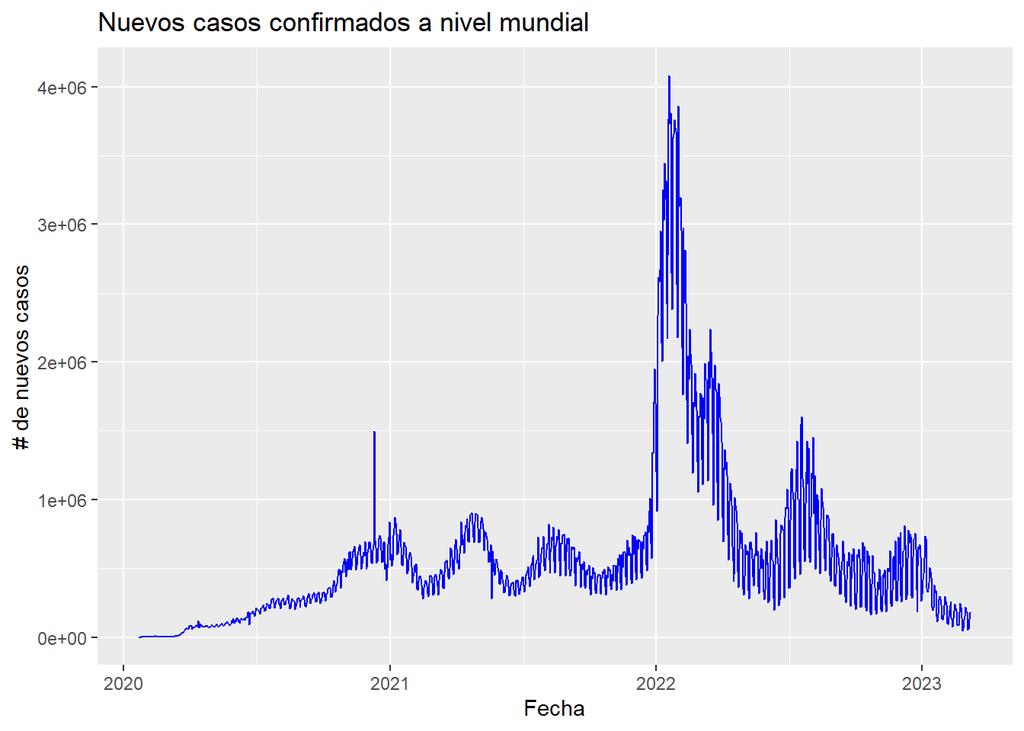

```r
casos |>
  # filtra tipo de dato que se quiere ver
  filter(type == "confirmed") |>
  # agrupar con dplyr para poder resumir los datos
  group_by(date) |>
  summarise(casos = sum(cases, na.rm = TRUE)) |>
  # graficar con ggplot
  ggplot(aes(x = date, y = casos))+
  geom_line(color = "blue")+
  labs(title = "Nuevos casos confirmados a nivel mundial",
       x = "Fecha",
       y = "# de nuevos casos")
```

- Acumulativo de nuevos casos confirmados en el tiempo.

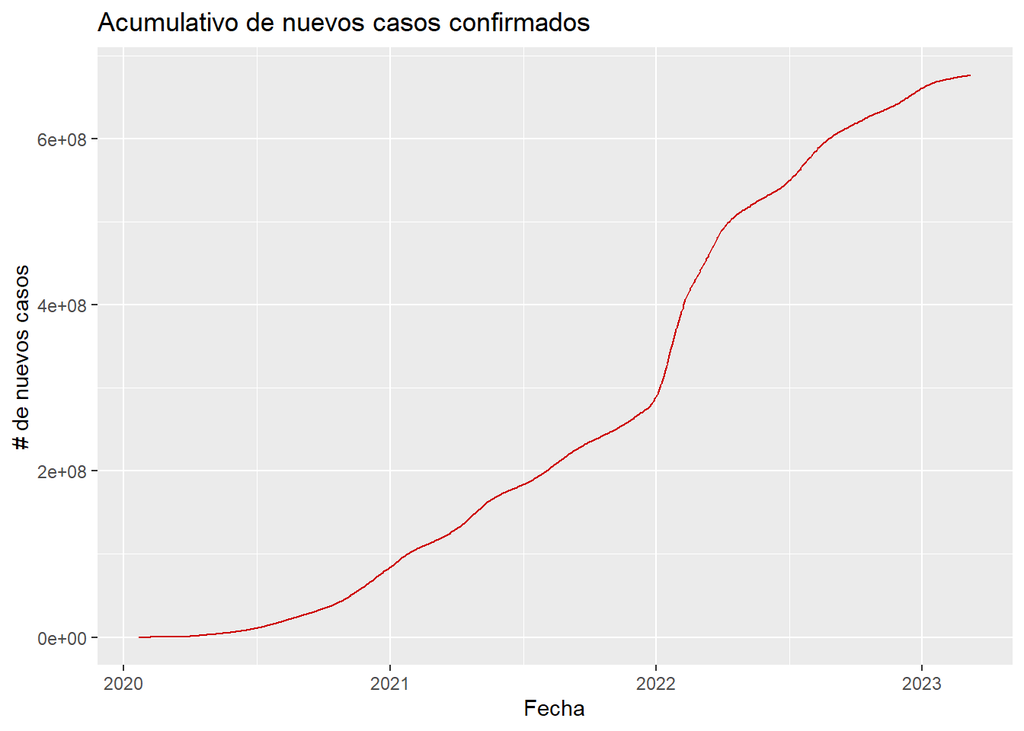

```r
# guardar los datos de nuevos casos
temp1 <- casos |>
  # filtrar tipo de datos que se quieren ver
  filter(type == "confirmed") |>
  # agrupar para resumir
  group_by(date) |>
  summarise(casos = sum(cases, na.rm = TRUE))

# agregar columna de datos acumulativos
temp1$acumulado = cumsum(temp1$casos)

# graficar
temp1 |>
  ggplot(aes(x = date, y = acumulado))+
  geom_line(color = "red3")+
  labs(title = "Acumulativo de nuevos casos confirmados",
       x = "Fecha",
       y = "# de nuevos casos")
```

- Defunciones reportadas a nivel mundial.

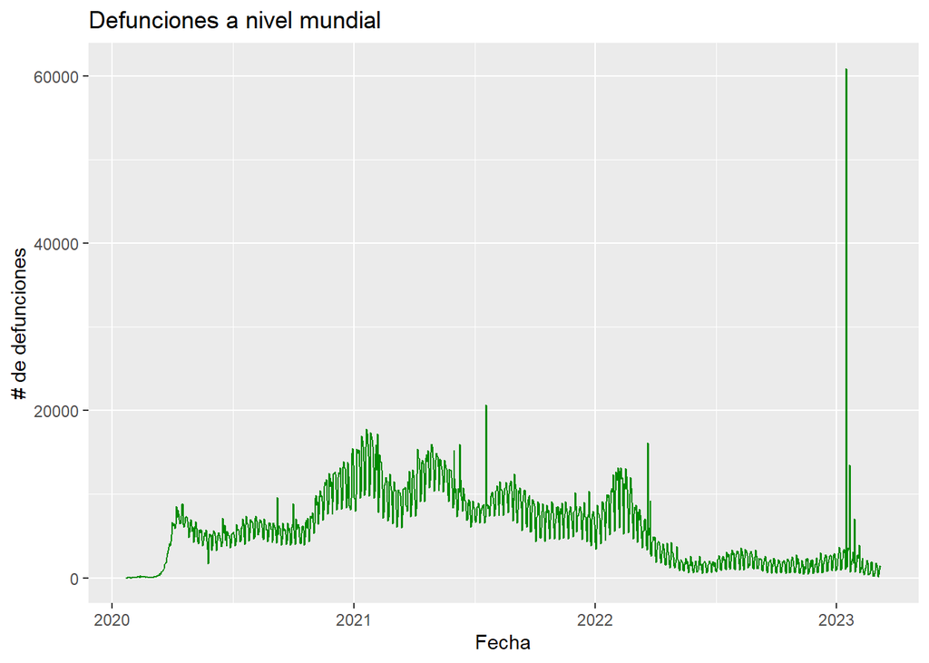

```r
casos |>
  # filtra tipo de dato que se quiere ver
  filter(type == "death") |>
  # agrupar con dplyr para poder resumir los datos
  group_by(date) |>
  summarise(casos = sum(cases, na.rm = TRUE)) |>
  # graficar con ggplot
  ggplot(aes(x = date, y = casos))+
  geom_line(color = "green4")+
  labs(title = "Defunciones a nivel mundial",
       x = "Fecha",
       y = "# de defunciones")
```

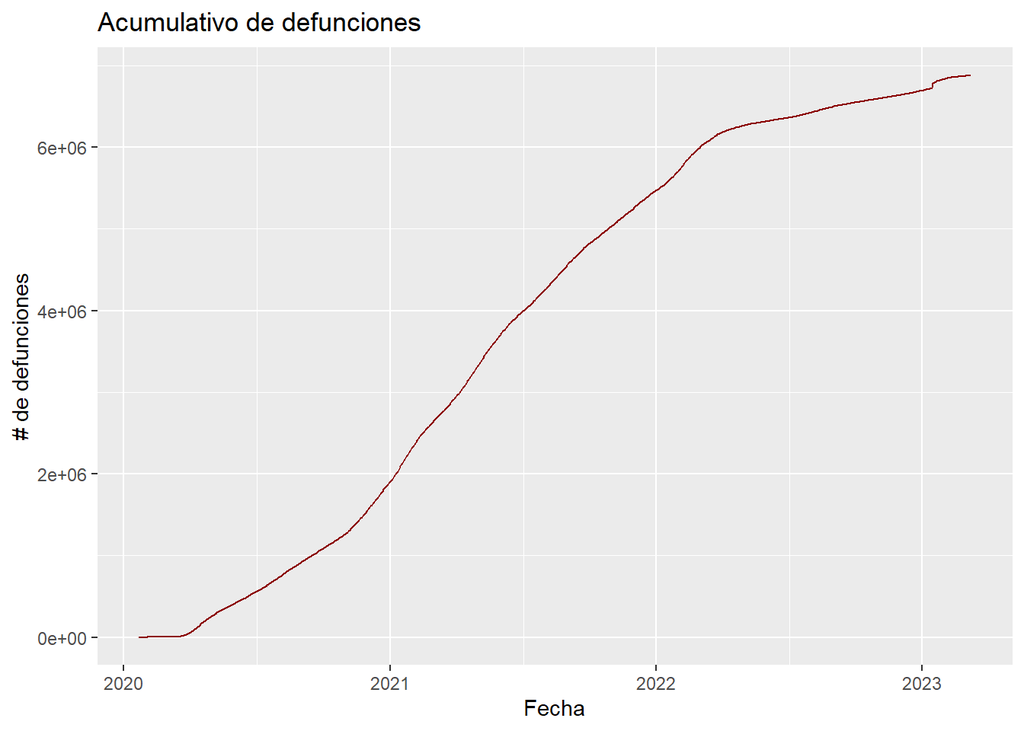

```r
temp1 <- casos |>
  # filtrar tipo de datos que se quieren ver
  filter(type == "death") |>
  # agrupar para resumir
  group_by(date) |>
  summarise(casos = sum(cases, na.rm = TRUE))

# agregar columna de datos acumulativos
temp1$acumulado = cumsum(temp1$casos)

# graficar
temp1 |>
  ggplot(aes(x = date, y = acumulado))+
  geom_line(color = "red4")+
  labs(title = "Acumulativo de defunciones",
       x = "Fecha",
       y = "# de defunciones")
```

- Casos confirmados y defunciones en Brasil (línea de tiempo sobre casos confirmados en Brasil).

```r
temp_bz <- casos |>
  # filtrar tipo de datos que se quieren ver
  filter(type != "recovery") |>
  filter(country == "Brazil") |>
  # agrupar para resumir
  group_by(date, type) |>
  summarise(casos = sum(cases, na.rm = TRUE)) |>
  pivot_wider(names_from = "type", values_from = "casos")
```

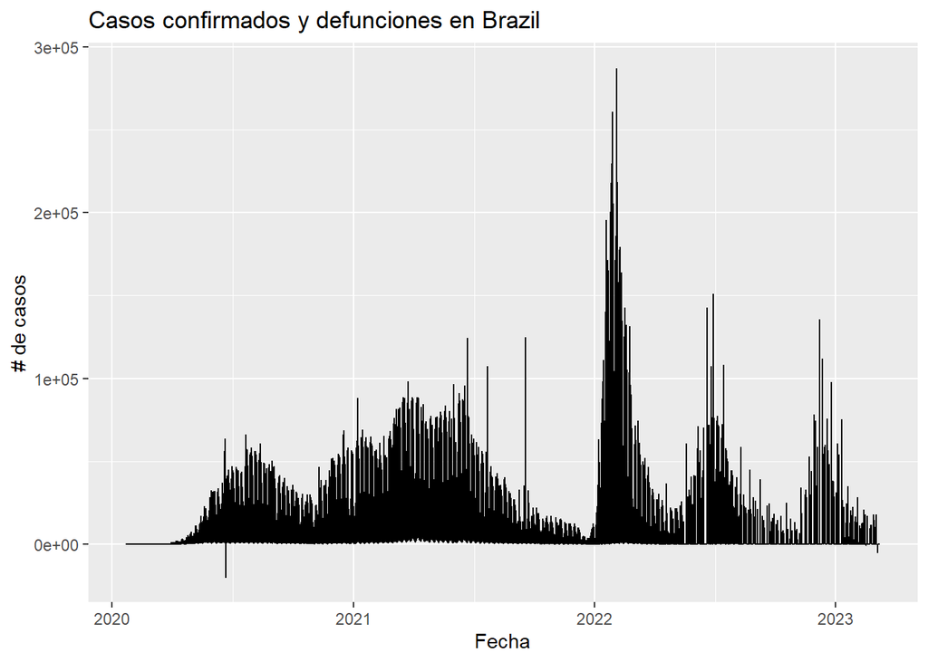

```r
# agregar columna de datos acumulativos

temp_bz$acumulado_confirmado = cumsum(temp_bz$confirmed)
temp_bz$acumulado_muerte = cumsum(temp_bz$death)

# graficar
temp_bz |>
  pivot_longer(cols = c(confirmed:acumulado_muerte),
               names_to = "Variable", values_to = "Cuenta") |>
  filter(Variable == "confirmed" | Variable == "death") |>
  ggplot(aes(x = date, y = Cuenta, color = Variable))+
  geom_line(color = "black")+
  labs(title = "Casos confirmados y defunciones en Brazil",
       x = "Fecha",
       y = "# de casos")
```

- Casos acumulados en Brazil

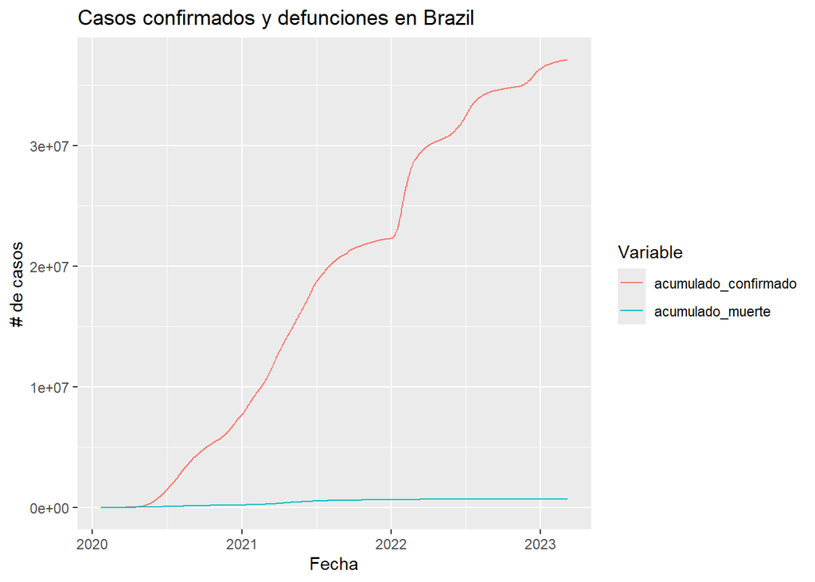

```r
# graficar
temp_bz |>
  pivot_longer(cols = c(confirmed:acumulado_muerte),
               names_to = "Variable", values_to = "Cuenta") |>
  filter(Variable == "acumulado_confirmado" | Variable == "acumulado_muerte") |>
  ggplot(aes(x = date, y = Cuenta, color = Variable))+
  geom_line()+
  labs(title = "Casos confirmados y defunciones en Brazil",
       x = "Fecha",
       y = "# de casos")
```

- Tasa de incidencia a nivel mundial por país, por año.
  - Presentar la información en un datatable, para facilitar el acceso a los datos.

```r
T_Incidencia <- casos |>
  # filtrar tipo de datos
  filter(type == "confirmed") |>
  # agrupar para después resumir los datos
  group_by(date, country) |>
  summarise(casos = sum(cases, na.rm = TRUE),
            poblacion = sum(population, na.rm = TRUE)) |>
  # agregar columna de año
  mutate(año = format(date, "%Y")) |>
  # deshacer los grupos anteriores para agrupar pero ahora por año
  ungroup() |>
  group_by(año, country) |>
  summarise(casos = sum(casos, na.rm = TRUE),
            poblacion = mean(poblacion, na.rm = TRUE)) |>
  # filtrar países con población 0, para evitar NaN e Infinitos
  filter(poblacion > 0) |>
  # calcular tasa de incidencia
  mutate(tasa_incidencia = casos / poblacion * 100000)
```

[output not shown]

```r
DT::datatable(T_Incidencia)
```

|  | año | country | casos | poblacion | tasa_incidencia |
| --- | --- | --- | --- | --- | --- |
| 1 | 2020 | Afghanistan | 52330 | 38928341 | 134.4264837795168 |
| 2 | 2020 | Albania | 58316 | 2877800 | 2026.409062478282 |
| 3 | 2020 | Algeria | 99610 | 43851043 | 227.1553723362977 |
| 4 | 2020 | Andorra | 8049 | 77265 | 10417.39468064453 |
| 5 | 2020 | Angola | 17553 | 32866268 | 53.40734153327053 |
| 6 | 2020 | Antigua and Barbuda | 159 | 97928 | 162.3641859325218 |
| 7 | 2020 | Argentina | 1625514 | 45195777 | 3596.605939532802 |
| 8 | 2020 | Armenia | 159409 | 2963234 | 5379.561654597645 |
| 9 | 2020 | Australia | 28425 | 25459700 | 111.6470343326905 |
| 10 | 2020 | Austria | 356063 | 9006400 | 3953.444217445372 |

[output cut: 758 more lines]

- Tasa de mortalidad a nivel mundial por país
- Presentar la información en un datatable, para facilitar el acceso a los datos.

```r
T_Mortalidad <- casos |>
  # filtrar tipo de datos
  filter(type == "death") |>
  # agrupar para después resumir los datos
  group_by(date, country) |>
  summarise(casos = sum(cases, na.rm = TRUE),
            poblacion = sum(population, na.rm = TRUE)) |>
  # agregar columna de año
  mutate(año = format(date, "%Y")) |>
  # deshacer los grupos anteriores para agrupar pero ahora por año
  ungroup() |>
  group_by(año, country) |>
  summarise(casos = sum(casos, na.rm = TRUE),
            poblacion = mean(poblacion, na.rm = TRUE)) |>
  # filtrar países con población 0, para evitar NaN e Infinitos
  filter(poblacion > 0) |>
  # calcular tasa de mortalidad
  mutate(tasa_mortalidad = casos / poblacion * 100000)
```

[output not shown]

```r
DT::datatable(T_Mortalidad)
```

|  | año | country | casos | poblacion | tasa_mortalidad |
| --- | --- | --- | --- | --- | --- |
| 1 | 2020 | Afghanistan | 2189 | 38928341 | 5.623152550991064 |
| 2 | 2020 | Albania | 1181 | 2877800 | 41.03829314059351 |
| 3 | 2020 | Algeria | 2756 | 43851043 | 6.284913223158682 |
| 4 | 2020 | Andorra | 84 | 77265 | 108.716754028344 |
| 5 | 2020 | Angola | 405 | 32866268 | 1.23226646846548 |
| 6 | 2020 | Antigua and Barbuda | 5 | 97928 | 5.105792010456662 |
| 7 | 2020 | Argentina | 43245 | 45195777 | 95.68371841466517 |
| 8 | 2020 | Armenia | 2823 | 2963234 | 95.26753540219909 |
| 9 | 2020 | Australia | 909 | 25459700 | 3.570348433013743 |
| 10 | 2020 | Austria | 7486 | 9006400 | 83.11867116717 |

[output cut: 758 more lines]

- Indicar valores de tasa de incidencia y mortalidad para Brazil

```r
# filtrar información a nivel país
T_Incidencia |>
  filter(country == "Brazil")
```

```
## # A tibble: 4 × 5
## # Groups:   año [4]
##   año   country    casos poblacion tasa_incidencia
##   <chr> <chr>      <dbl>     <dbl>           <dbl>
## 1 2020  Brazil   7681032 212559409           3614.
## 2 2021  Brazil  14610807 212559409           6874.
## 3 2022  Brazil  14039442 212559409           6605.
## 4 2023  Brazil    744772 212559409            350.
```

```r
# filtrar información a nivel país
T_Mortalidad |>
  filter(country == "Brazil")
```

```
## # A tibble: 4 × 5
## # Groups:   año [4]
##   año   country  casos poblacion tasa_mortalidad
##   <chr> <chr>    <dbl>     <dbl>           <dbl>
## 1 2020  Brazil  195072 212559409           91.8
## 2 2021  Brazil  424262 212559409          200.
## 3 2022  Brazil   74519 212559409           35.1
## 4 2023  Brazil    5423 212559409            2.55
```

## Conclusiones

- Se pueden escribir un párrafo o dos con respecto a los resultados observados y a la situación del COVID19 a cuatro años de haber iniciado la pandemia.

## Bibliografía

- Se agregan las referencias necesarias para citar los documentos y reportes utilizados.
- Se debe incluir también la cita al paquete de datos `coronavirus` de R.

# Pasos a seguir para subir el reporte a GitHub

1. Crear el repositorio en la web de GitHub. Se puede sugerir un nombre como “visualizacion_COVID19”.
2. Copiar la URL del repositorio remoto.
3. Pasar a la terminal en RStudio.
4. Verificar que el directorio de trabajo coincida con el directorio en donde está el reporte.
5. Inicializar el repositorio local `git init`
6. Añadir el archivo al área de preparación `git add Sesion2_Actividad.md`
7. Confirmar los cambios `git commit -m "Se carga archivo de reporte"`
8. Asignar un nombre de rama `git branch -M main`
9. Conectar los repositorios local y remoto `git remote add origin https://github.com/xxxUsrNmxxx/visualizacion_COVID19.git`
10. Llevar los cambios locales al repositorio remoto `git push -u origin main`

> [Nota]

> En caso de que RStudio no permita usar el nombre de usuario y contraseña para hacer la conexión remota se puede usar en vez de la contraseña un **Access token**.
> 1. En la página de GitHub hacer click en el ícono de perfil y luego en “Settings”.
> 2. En el menú del lado izquierdo, hacer click en la última opción “Developer settings”.
> 3. En el menú del lado izquierdo, hacer click en “Personal access tokens” y después en “Fine-grained tokens”.
> 4. Del lado derecho aparece el botón de “Generate new token”, hacer click ahí y confirmar con contraseña.
> 5. Se puede dar un nombre al token “Visualizacion COVID19”, cambiar el tiempo de expiración a 90 días y agregar alguna descripción. En la sección de “Repository access” seleccionar la tercera opción “Only select repositories” y escoger el repo adecuado.
> 6. Otorgar permisos adecuados. Para **Repository permissions** habilitar Actions, Administration, Commit statuses, Contents, Deployments, Environments, Metadata, Pages, Pull requests. Para **Account permissions** habilitar todo.
> 7. Copiar el token generado y usarlo como contraseña cuándo se hace el push.